# AI-Fall 01-CA0

University of Tehran

Saman Eslami Nazari - std id: 810199375

##### 1.

```python
import pandas as pd

TRAIN_DATA_SET = 'assets/train.csv'
df = pd.read_csv(TRAIN_DATA_SET)
```

`describe` method:  
This method gives general information about each column in DataFrame. These information are listed below:

- count: the count of non-Nan values.
- mean
- std: standard deviation
- min: minimum value of the column
- 25%, 50% and 75% percentiles
- max: the maximum value of the column No need to say that these information are for numerical values in the DataFrame.

```python
print('describe method:')
display(df.describe())
```

```
describe method:
```

|  | PassengerId | Survived | Pclass | Age | SibSp | Parch | Fare |
| --- | --- | --- | --- | --- | --- | --- | --- |
| count | 891.000000 | 891.000000 | 891.000000 | 714.000000 | 891.000000 | 891.000000 | 891.000000 |
| mean | 446.000000 | 0.383838 | 2.308642 | 29.699118 | 0.523008 | 0.381594 | 32.204208 |
| std | 257.353842 | 0.486592 | 0.836071 | 14.526497 | 1.102743 | 0.806057 | 49.693429 |
| min | 1.000000 | 0.000000 | 1.000000 | 0.420000 | 0.000000 | 0.000000 | 0.000000 |
| 25% | 223.500000 | 0.000000 | 2.000000 | 20.125000 | 0.000000 | 0.000000 | 7.910400 |
| 50% | 446.000000 | 0.000000 | 3.000000 | 28.000000 | 0.000000 | 0.000000 | 14.454200 |
| 75% | 668.500000 | 1.000000 | 3.000000 | 38.000000 | 1.000000 | 0.000000 | 31.000000 |
| max | 891.000000 | 1.000000 | 3.000000 | 80.000000 | 8.000000 | 6.000000 | 512.329200 |

`head` and `tail` methods:  
These methods accept number `n` as their input and shows n first and last values of the DataFrame respectively.  
`n` is set to 5 by default.

```python
print('head and tail methods:')
display(df.head(10))
display(df.tail(10))
```

```
head and tail methods:
```

|  | PassengerId | Survived | Pclass | Name | Sex | Age | SibSp | Parch | Ticket | Fare | Cabin | Embarked |
| --- | --- | --- | --- | --- | --- | --- | --- | --- | --- | --- | --- | --- |
| 0 | 1 | 0 | 3 | Braund, Mr. Owen Harris | male | 22.0 | 1 | 0 | A/5 21171 | 7.2500 | NaN | S |
| 1 | 2 | 1 | 1 | Cumings, Mrs. John Bradley (Florence Briggs Th... | female | 38.0 | 1 | 0 | PC 17599 | 71.2833 | C85 | C |
| 2 | 3 | 1 | 3 | Heikkinen, Miss. Laina | female | 26.0 | 0 | 0 | STON/O2. 3101282 | 7.9250 | NaN | S |
| 3 | 4 | 1 | 1 | Futrelle, Mrs. Jacques Heath (Lily May Peel) | female | 35.0 | 1 | 0 | 113803 | 53.1000 | C123 | S |
| 4 | 5 | 0 | 3 | Allen, Mr. William Henry | male | 35.0 | 0 | 0 | 373450 | 8.0500 | NaN | S |
| 5 | 6 | 0 | 3 | Moran, Mr. James | male | NaN | 0 | 0 | 330877 | 8.4583 | NaN | Q |
| 6 | 7 | 0 | 1 | McCarthy, Mr. Timothy J | male | 54.0 | 0 | 0 | 17463 | 51.8625 | E46 | S |
| 7 | 8 | 0 | 3 | Palsson, Master. Gosta Leonard | male | 2.0 | 3 | 1 | 349909 | 21.0750 | NaN | S |
| 8 | 9 | 1 | 3 | Johnson, Mrs. Oscar W (Elisabeth Vilhelmina Berg) | female | 27.0 | 0 | 2 | 347742 | 11.1333 | NaN | S |
| 9 | 10 | 1 | 2 | Nasser, Mrs. Nicholas (Adele Achem) | female | 14.0 | 1 | 0 | 237736 | 30.0708 | NaN | C |

|  | PassengerId | Survived | Pclass | Name | Sex | Age | SibSp | Parch | Ticket | Fare | Cabin | Embarked |
| --- | --- | --- | --- | --- | --- | --- | --- | --- | --- | --- | --- | --- |
| 881 | 882 | 0 | 3 | Markun, Mr. Johann | male | 33.0 | 0 | 0 | 349257 | 7.8958 | NaN | S |
| 882 | 883 | 0 | 3 | Dahlberg, Miss. Gerda Ulrika | female | 22.0 | 0 | 0 | 7552 | 10.5167 | NaN | S |
| 883 | 884 | 0 | 2 | Banfield, Mr. Frederick James | male | 28.0 | 0 | 0 | C.A./SOTON 34068 | 10.5000 | NaN | S |
| 884 | 885 | 0 | 3 | Sutehall, Mr. Henry Jr | male | 25.0 | 0 | 0 | SOTON/OQ 392076 | 7.0500 | NaN | S |
| 885 | 886 | 0 | 3 | Rice, Mrs. William (Margaret Norton) | female | 39.0 | 0 | 5 | 382652 | 29.1250 | NaN | Q |
| 886 | 887 | 0 | 2 | Montvila, Rev. Juozas | male | 27.0 | 0 | 0 | 211536 | 13.0000 | NaN | S |
| 887 | 888 | 1 | 1 | Graham, Miss. Margaret Edith | female | 19.0 | 0 | 0 | 112053 | 30.0000 | B42 | S |
| 888 | 889 | 0 | 3 | Johnston, Miss. Catherine Helen "Carrie" | female | NaN | 1 | 2 | W./C. 6607 | 23.4500 | NaN | S |
| 889 | 890 | 1 | 1 | Behr, Mr. Karl Howell | male | 26.0 | 0 | 0 | 111369 | 30.0000 | C148 | C |
| 890 | 891 | 0 | 3 | Dooley, Mr. Patrick | male | 32.0 | 0 | 0 | 370376 | 7.7500 | NaN | Q |

`info` method:  
This method gives the below information about the whole DataFrame:

- Range index
- Columns count
- Columns label
- Columns non-Nan values count
- Column data type
- Memory usage

```python
print('info method:')
display(df.info())
```

```
info method:
<class 'pandas.core.frame.DataFrame'>
RangeIndex: 891 entries, 0 to 890
Data columns (total 12 columns):
 #   Column       Non-Null Count  Dtype
---  ------       --------------  -----
 0   PassengerId  891 non-null    int64
 1   Survived     891 non-null    int64
 2   Pclass       891 non-null    int64
 3   Name         891 non-null    object
 4   Sex          891 non-null    object
 5   Age          714 non-null    float64
 6   SibSp        891 non-null    int64
 7   Parch        891 non-null    int64
 8   Ticket       891 non-null    object
 9   Fare         891 non-null    float64
 10  Cabin        204 non-null    object
 11  Embarked     889 non-null    object
dtypes: float64(2), int64(5), object(5)
memory usage: 83.7+ KB
```

```
None
```

##### 2.

First, I call the `info()` method as wanted. Then I will map the "Sex" Column values to 0s and 1s.  
There are also libraries like Sci-kit learn that are easier to use.

```python
df.info()


def encode_label(df: pd.DataFrame, label: str):
    label_codes = dict(
        zip(
            df[label].loc[df[label].notna()].astype('category').cat.categories,
            df[label].loc[df[label].notna()].astype('category').cat.codes
        )
    )
    encoded_df = df[label].map(label_codes)
    return label_codes, encoded_df


# Label encoding 'Sex' column:
sex_label_cods, df['Sex'] = encode_label(df, 'Sex')

# Label encoding 'Embarked' column:
embarked_label_encoding, df['Embarked'] = encode_label(df, 'Embarked')
```

```
<class 'pandas.core.frame.DataFrame'>
RangeIndex: 891 entries, 0 to 890
Data columns (total 12 columns):
 #   Column       Non-Null Count  Dtype
---  ------       --------------  -----
 0   PassengerId  891 non-null    int64
 1   Survived     891 non-null    int64
 2   Pclass       891 non-null    int64
 3   Name         891 non-null    object
 4   Sex          891 non-null    object
 5   Age          714 non-null    float64
 6   SibSp        891 non-null    int64
 7   Parch        891 non-null    int64
 8   Ticket       891 non-null    object
 9   Fare         891 non-null    float64
 10  Cabin        204 non-null    object
 11  Embarked     889 non-null    object
dtypes: float64(2), int64(5), object(5)
memory usage: 83.7+ KB
```

Now, I call the `head` method to see the "Sex" column mapping result.

```python
df.head()
```

|  | PassengerId | Survived | Pclass | Name | Sex | Age | SibSp | Parch | Ticket | Fare | Cabin | Embarked |
| --- | --- | --- | --- | --- | --- | --- | --- | --- | --- | --- | --- | --- |
| 0 | 1 | 0 | 3 | Braund, Mr. Owen Harris | 0 | 22.0 | 1 | 0 | A/5 21171 | 7.2500 | NaN | 2.0 |
| 1 | 2 | 1 | 1 | Cumings, Mrs. John Bradley (Florence Briggs Th... | 1 | 38.0 | 1 | 0 | PC 17599 | 71.2833 | C85 | 2.0 |
| 2 | 3 | 1 | 3 | Heikkinen, Miss. Laina | 1 | 26.0 | 0 | 0 | STON/O2. 3101282 | 7.9250 | NaN | 2.0 |
| 3 | 4 | 1 | 1 | Futrelle, Mrs. Jacques Heath (Lily May Peel) | 1 | 35.0 | 1 | 0 | 113803 | 53.1000 | C123 | 2.0 |
| 4 | 5 | 0 | 3 | Allen, Mr. William Henry | 0 | 35.0 | 0 | 0 | 373450 | 8.0500 | NaN | 2.0 |

As it can bee seen above, The "Sex" and "Embarked" columns are encoded with numeric values. The validity of data can be checked by comparing this section with `head` and `tail` methods" part of this one.

##### 3.

The count of missing values in each column is shown below:

```python
df[df.columns].isna().sum()
```

```
PassengerId      0
Survived         0
Pclass           0
Name             0
Sex              0
Age            177
SibSp            0
Parch            0
Ticket           0
Fare             0
Cabin          687
Embarked         2
dtype: int64
```

Here I will only fill missing values of the "Age" column. The "Cabin" column will be removed in the next part. Also "Embarked" column has very few missing values and can be ignored.

```python
df['Age'].fillna(df['Age'].mean(), inplace=True)
#To show that there aren't missing values any more:
df['Age'].isna().sum()
```

```
0
```

Pros and Cons of using mean to fill Nan Values:

- Pros:
  - It is easy and simple to use mean for imputing data.
  - It gives a good representation of the whole data.
- Cons:
  - Sometime the newly imputed data doesn't make sense. This mostly happens when we're using mean for rows that are logically outliers. A better solution to this problem can be deducting values from their correlated columns.
  - Using mean can corrupt variance.
  - Using mean ignores correlation between features.

##### 4.

```python
df = df.drop(['PassengerId', 'Cabin', 'Ticket', 'Name'],  axis=1)
df = df[df['Embarked'].notna()]
df[df.columns].isna().sum()
```

```
Survived    0
Pclass      0
Sex         0
Age         0
SibSp       0
Parch       0
Fare        0
Embarked    0
dtype: int64
```

##### 5.

For this purpose I'll use `loc` method.

Number of female passengers:

```python
df.loc[df['Sex'] == sex_label_cods['female']].shape[0]
```

```
312
```

Number of male passengers:

```python
df.loc[df['Sex'] == sex_label_cods['male']].shape[0]
```

```
577
```

```python
df.loc[
    (df['Sex'] == sex_label_cods['male']) &
    (df['Embarked'] == embarked_label_encoding['S'])
].shape[0]
```

```
536
```

##### 6.

Number of people older than 35 who are alone (they don't have siblings or parents with them on board) and have a Pclass of 3.

```python
df.loc[
    (df['Age'] > 35) &
    (df['Pclass'] == 3) &
    (df['SibSp'] == 0) &
    (df['Parch'] == 0)
].shape[0]
```

```
41
```

##### 7.

Below is the mean of passengers' fare who embarked in Queenstown. I also measure the runtime to compare it with a non-vectorized method.

```python
def mean_vec():
    return df[df['Embarked'] == 0]['Fare'].mean()

print('mean: ', mean_vec())
```

```
mean:  13.276029870129872
```

##### 8.

Here I'll calculate the previous section without vectorization and compare the running time. I also print the mean in both section to make sure the calculations are correct.

```python
def mean_not_vec():
    sum = 0
    cnt = 0
    for index, row in df.iterrows():
        if row['Embarked'] == 0:
            sum += row['Fare']
            cnt += 1
    return sum / cnt

print('mean: ', mean_not_vec())
```

```
mean:  13.276029870129872
```

Now to measure the timing difference between vectorized and non-vectorized methods, I will do as below:

```python
from timeit import timeit

VEC_SETUP = '''
from __main__ import mean_vec
'''
VECTORIZED_CODE = '''
mean_vec()
'''

NOT_VEC_SETUP = '''
from __main__ import mean_not_vec
'''
NON_VECTORIZED_CODE = '''
mean_not_vec()
'''

print(timeit(setup=VEC_SETUP, stmt=VECTORIZED_CODE, number=100) / 100)
print(timeit(setup=NOT_VEC_SETUP, stmt=NON_VECTORIZED_CODE, number=100) / 100)
```

```
0.0004939309999997477
0.02683008500000028
```

As expected non-vectorized code runs slower.

##### 9.

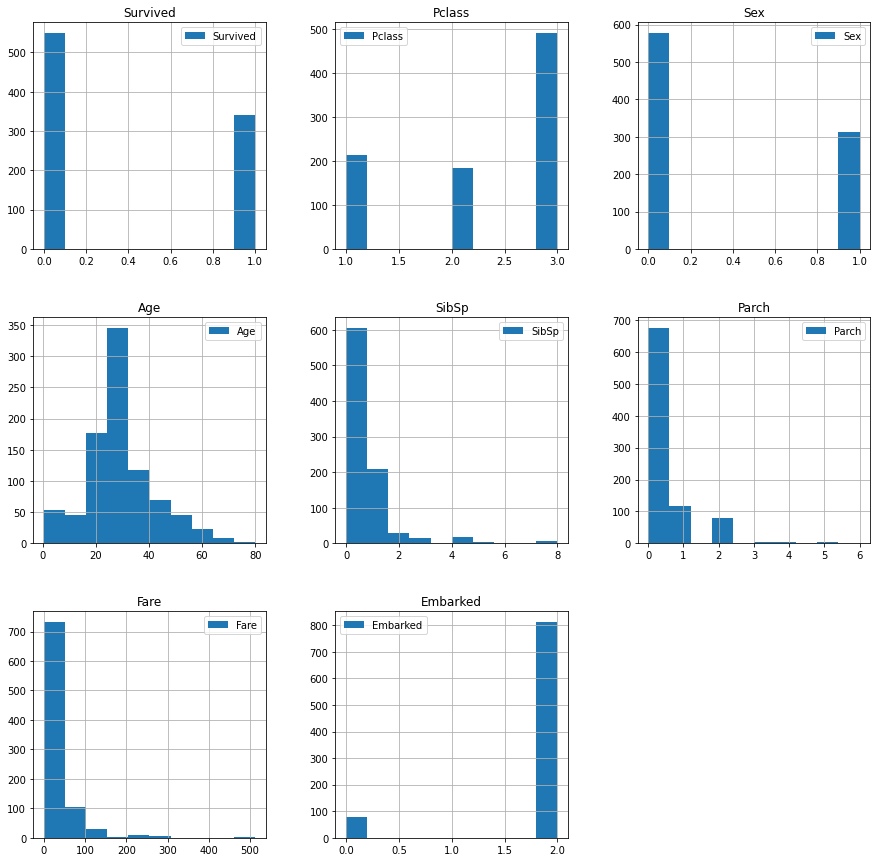

```python
df.hist(figsize=(15, 15), legend=True);
```

##### 10.

Normalizing data by subtracting mean and dividing the result by std:

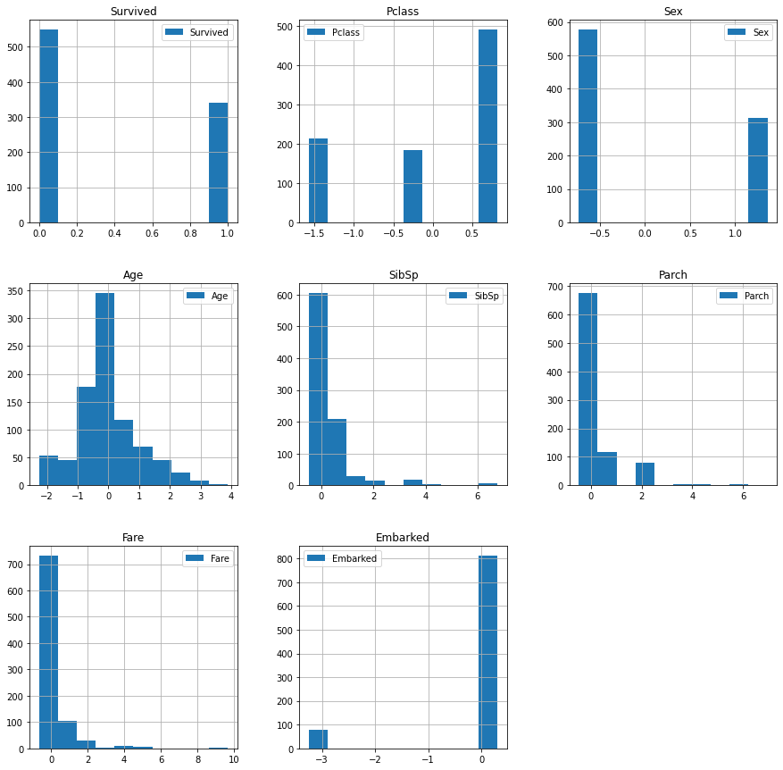

```python
import numpy as np


def normalize(df: pd.DataFrame):
    return (df - df.mean()) / df.std()


selected_columns = df.select_dtypes(include=np.number).columns.drop('Survived')
df[selected_columns] = normalize(df[selected_columns])
df.hist(figsize=(15, 15), legend=True);
```

```python
print(df[selected_columns].mean())
print(df[selected_columns].std())
```

```
Pclass     -1.878263e-16
Sex        -6.394085e-17
Age         3.157080e-16
SibSp      -7.992607e-18
Parch      -4.795564e-17
Fare        1.358743e-16
Embarked   -1.958189e-16
dtype: float64
Pclass      1.0
Sex         1.0
Age         1.0
SibSp       1.0
Parch       1.0
Fare        1.0
Embarked    1.0
dtype: float64
```

As it can be seen from the diagram and the mean and std tables, data has been successfully normalized and fit into a distribution with mean=0 and std=1

##### 11.

First I will calculate mean and std of features for both the passengers who survived and who didn't.

```python
survived_df = df[selected_columns].loc[df['Survived'] == 1]
not_survived_df = df[selected_columns].loc[df['Survived'] == 0]

survived_mean = survived_df.mean()
survived_std = survived_df.std()

not_survived_mean = not_survived_df.mean()
not_survived_std = not_survived_df.std()

features_stats_df = pd.DataFrame(
    {
        'survived_mean': survived_mean,
        'survived_std': survived_std,
        'not_survived_mean': not_survived_mean,
        'not_survived_std': not_survived_std
    }
)

features_stats_df
```

|  | survived_mean | survived_std | not_survived_mean | not_survived_std |
| --- | --- | --- | --- | --- |
| Pclass | -0.426146 | 1.033621 | 0.263915 | 0.881521 |
| Sex | 0.687811 | 0.978751 | -0.425967 | 0.743329 |
| Age | -0.094834 | 1.055095 | 0.058732 | 0.960597 |
| SibSp | -0.043231 | 0.643141 | 0.026773 | 1.167340 |
| Parch | 0.105601 | 0.958346 | -0.065400 | 1.020335 |
| Fare | 0.324218 | 1.343101 | -0.200791 | 0.631585 |
| Embarked | -0.005760 | 1.009337 | 0.003567 | 0.995081 |

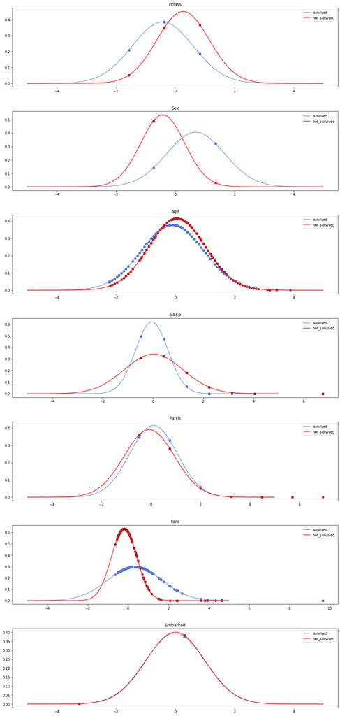

```python
import matplotlib.pyplot as plt
import scipy.stats as stats

features_cnt = features_stats_df.shape[0]

fig, axes = plt.subplots(nrows=features_cnt, figsize=(15, 30))
fig.tight_layout(pad=5.0)

x = np.arange(-5, 5, 0.01)

ax_index = 0
for index, row in features_stats_df.iterrows():
    axes[ax_index].plot(
        x,
        stats.norm.pdf(
            x, loc=row['survived_mean'], scale=row['survived_std']
        ),
        label='survived',
        color='cornflowerblue'
    )
    axes[ax_index].scatter(
        survived_df[row.name],
        stats.norm.pdf(
            survived_df[row.name],
            loc=row['survived_mean'],
            scale=row['survived_std']
        ),
        color='royalblue'
    )

    axes[ax_index].plot(
        x,
        stats.norm.pdf(
            x, loc=row['not_survived_mean'], scale=row['not_survived_std']
        ),
        label='not_survived',
        color='red'
    )
    axes[ax_index].scatter(
        not_survived_df[row.name],
        stats.norm.pdf(
            not_survived_df[row.name],
            loc=row['not_survived_mean'],
            scale=row['not_survived_std']
        ),
        color='firebrick'
    )

    axes[ax_index].set_title(row.name)
    axes[ax_index].legend()
    ax_index += 1
```

I'll choose the feature that the passengers' survival has more effect on it. This means that a feature is better if there is more difference between its $f(feature | survived)$ and $f(feature | not survived)$ plots. Therefore I choose "Sex" column to predict 'test.csv'

```python
selected_feature = 'Sex'
```

##### 12.

Before rushing into any conclusion, I will do a feature accuracy test.

```python
from sklearn.model_selection import train_test_split
from sklearn.metrics import accuracy_score

x_data = df[selected_columns]
y_data = df['Survived']
x_train, x_test, y_train, y_test = train_test_split(
    x_data, y_data, test_size=0.2)

x_train_survived = x_train.loc[y_train == 1]
x_train_not_survived = x_train.loc[y_train == 0]

test_survived_pdf = pd.DataFrame(
    stats.norm.pdf(
        x_test,
        loc=x_train_survived.mean(),
        scale=x_train_survived.std()),
    columns=selected_columns
)

test_not_survived_pdf = pd.DataFrame(
    stats.norm.pdf(
        x_test,
        loc=x_train_not_survived.mean(),
        scale=x_train_not_survived.std()),
    columns=selected_columns
)

assert test_not_survived_pdf.shape == test_survived_pdf.shape

test_pred = pd.DataFrame(
    np.where(test_survived_pdf > test_not_survived_pdf, 1, 0),
    columns=selected_columns
)

for column in selected_columns:
    print(f"{column} evaluation: {accuracy_score(test_pred[column], y_test) * 100:.2f}%")
```

```
Pclass evaluation: 65.17%
Sex evaluation: 79.78%
Age evaluation: 58.43%
SibSp evaluation: 37.08%
Parch evaluation: 62.36%
Fare evaluation: 69.66%
Embarked evaluation: 33.71%
```

The above result proves the correction of my choice.

```python
TEST_FILE = "assets/test.csv"
test_df = pd.read_csv(TEST_FILE)

test_sex_codes, test_df['Sex'] = encode_label(test_df, 'Sex')
test_df = normalize(test_df)


def pred_survival(feature: pd.Series):
    pred_survived_df = pd.Series(
        stats.norm.pdf(
            feature,
            loc=features_stats_df['survived_mean'][selected_feature],
            scale=features_stats_df['survived_std'][selected_feature]
        )
    )

    pred_not_survived_df = pd.Series(
        stats.norm.pdf(
            feature,
            loc=features_stats_df['not_survived_mean'][selected_feature],
            scale=features_stats_df['not_survived_std'][selected_feature]
        )
    )

    return pd.DataFrame(
        np.where(pred_survived_df > pred_not_survived_df, 1, 0),
        columns=['Survived']
    )


result = pred_survival(test_df[selected_feature])

RESULT_FILE = 'result.csv'
result.to_csv(RESULT_FILE)
```